# R crash course / 05

## Simple basic plots (demonstration)

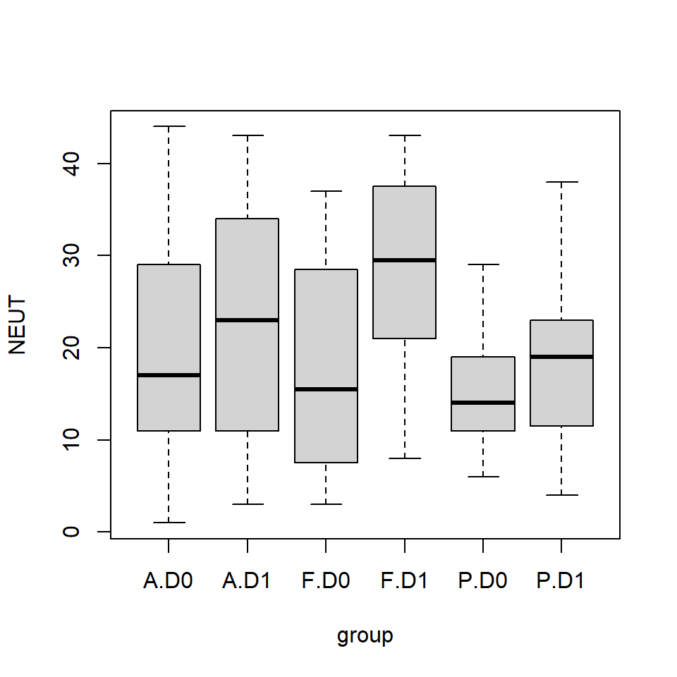

## Simple basic plots (demonstration)

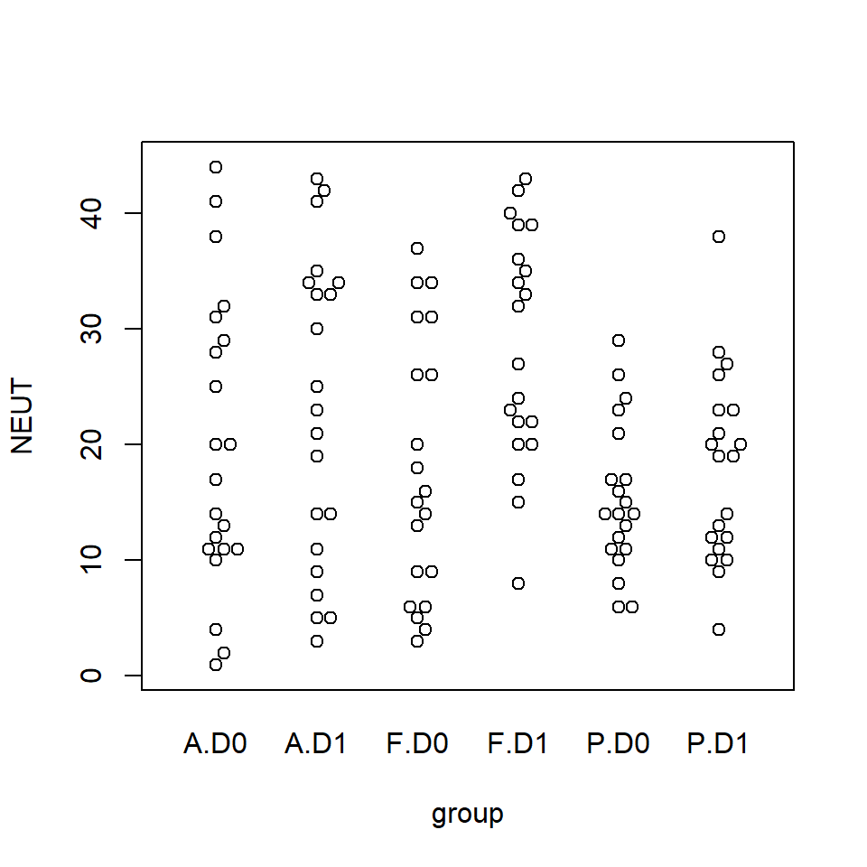

```r
library(beeswarm)
beeswarm(NEUT ~ group, data=labwide)
```

## Excercise 5.2

- Create box plots for selected variables

## ggplot2 vs basic R plots

Basic R plots:

- super simple for a beginner
- messy if you try to make it nice
- you can do anything
- some tools only produce basic R
- SUPER fast

ggplot2:

- produces nice and complex graphics with less effort
- requires a data frame
- more uniform
- very different syntax
- some things really hard to achieve

## Plot for pairwise data

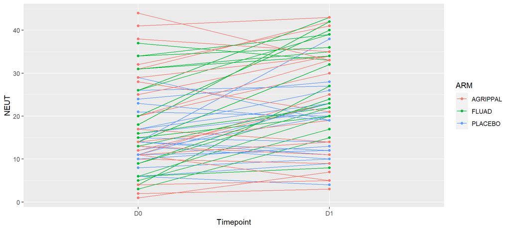

```r
library(ggplot2)
ggplot(labwide, aes(x=Timepoint, y=NEUT, group=USUBJID, color=ARM)) + geom_line() + geom_point()
```

## Making it nicer

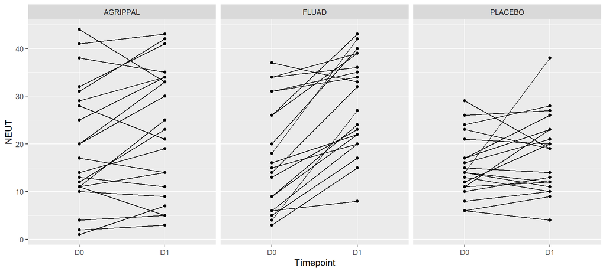

```r
ggplot(labwide, aes(x=Timepoint, y=NEUT, group=USUBJID)) + geom_line() + geom_point() +
  facet_grid(. ~ ARM)
```

## Making it nicer

```r
ggplot(labwide, aes(x=Timepoint, y=NEUT, group=USUBJID)) +
  geom_line(color="grey") +
  geom_point() +
  facet_grid(. ~ ARM) +
  xlab("Day") +
  ylab("Neutrophiles") +
  theme_bw() +
  ggtitle("Change in neutrophile count in different study arms")
```

## Making it nicer

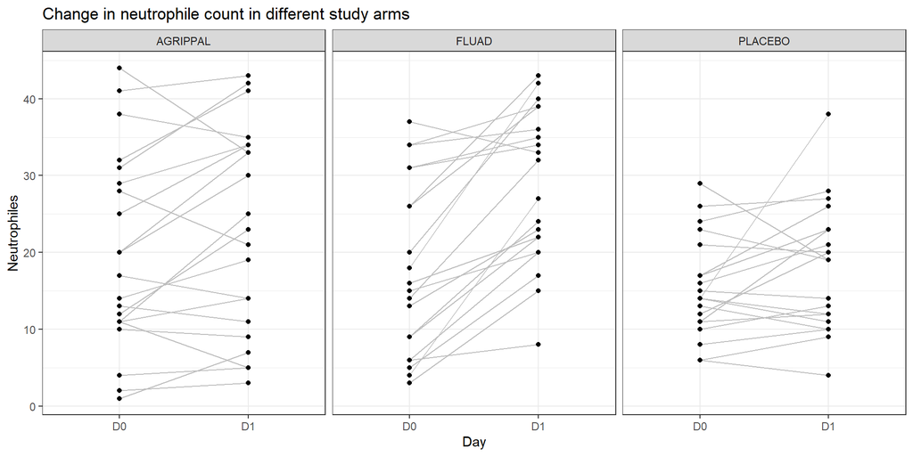

## SD, SEM and different plot types

## SD vs SEM

```r
## generate mock data sets with different sample sizes
ns <- c(10, 50, 100, 500)
data <- rnorm(sum(ns))
## repeat "a" 10 times, "b" 50 times, etc.
labs <- unlist(lapply(1:length(ns),
  function(i) rep(letters[i], ns[i])))

## calculate means, SD and SEM
means <- tapply(data, labs, mean)
sds <- tapply(data, labs, sd)
ses <- sds/sqrt(ns)
```

## SD vs SEM (cont.)

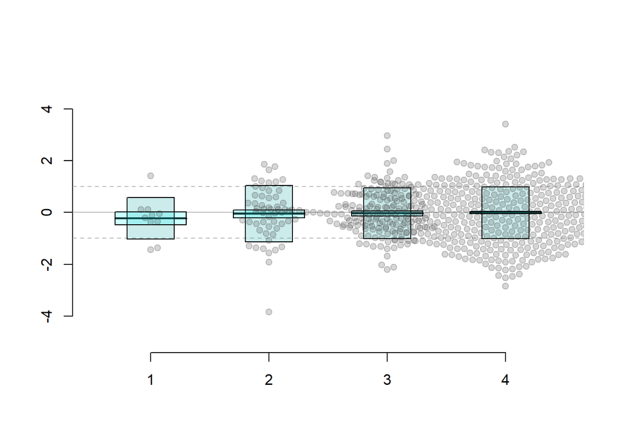

## Function for plotting error bars

```r
ebar <- function(x, y, sd, width=1, ...) {
  w <- width/2

  segments(x, y, x, y + sd, ...)
  segments(x - w, y + sd, x + w, y + sd, ...)
}
```

## SD vs SEM (cont.)

p < 0.00039

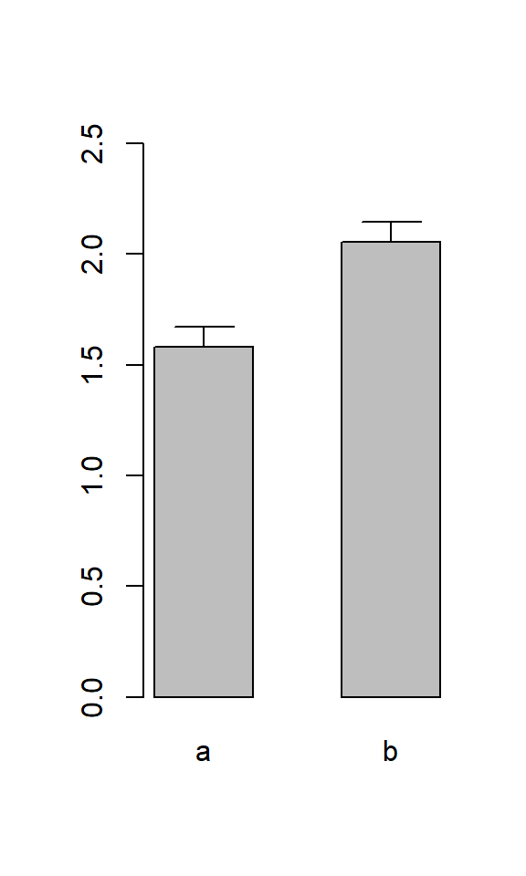

## SD vs SEM (cont.)

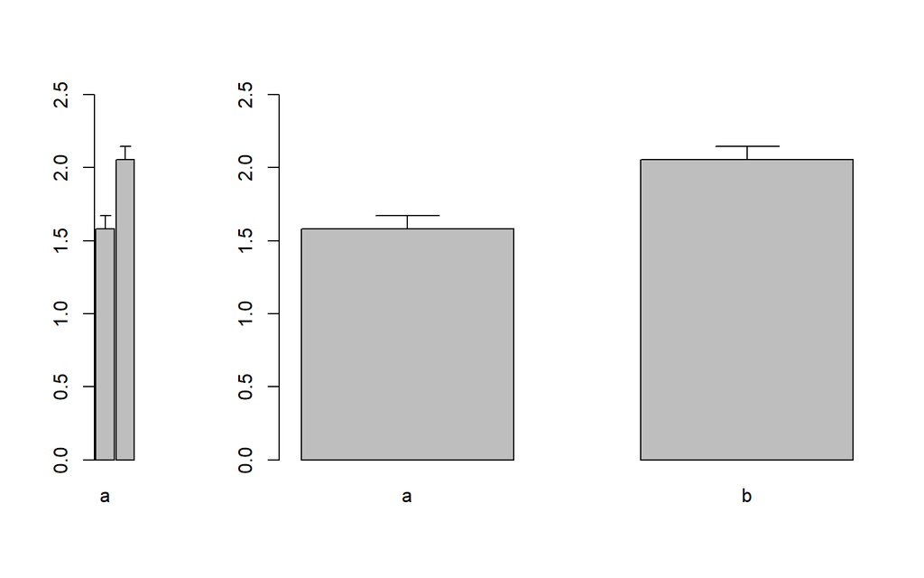

## SD vs SEM (cont.)

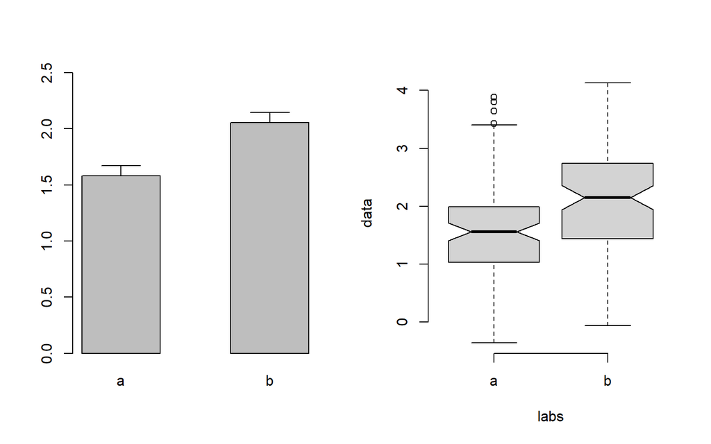

## SD vs SEM (cont.)

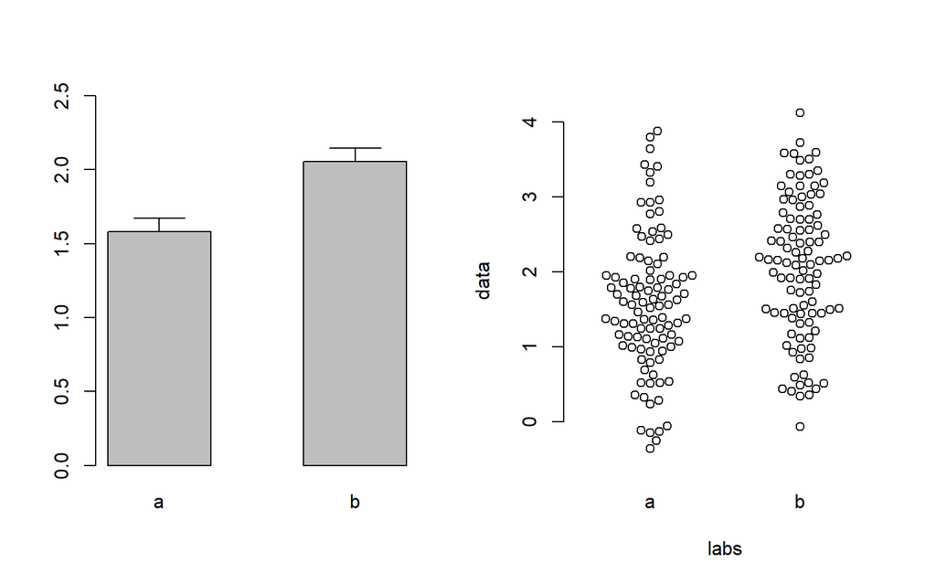

## SD vs SEM (cont.)

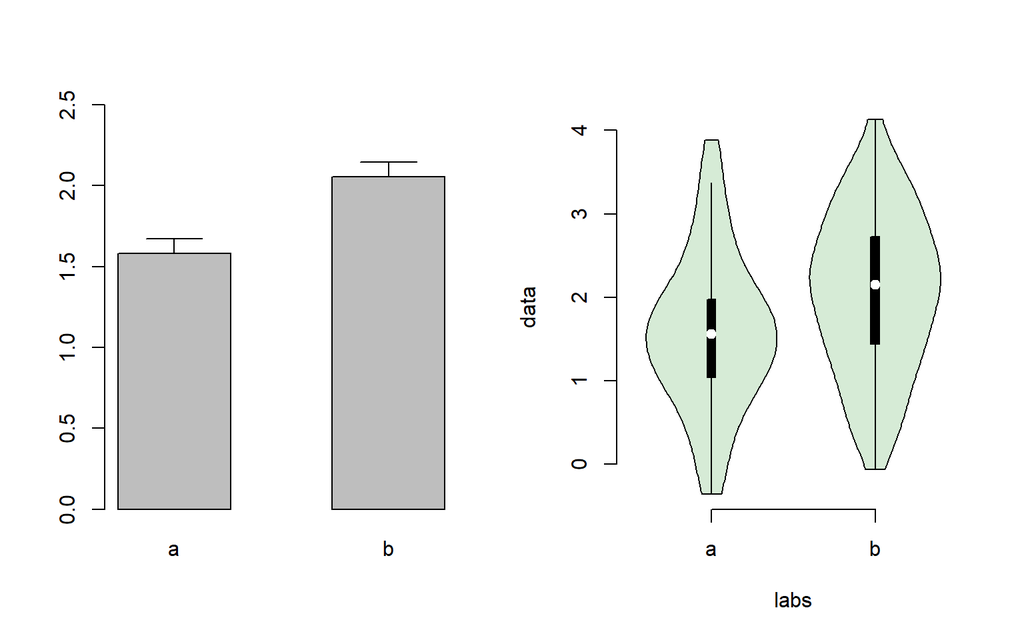

# Multivariate data

## PCA

```r
data(iris)
theme_set(theme_bw())
pca <- prcomp(iris[,1:4], scale.=TRUE)
df <- data.frame(pca$x, species=iris$Species)
ggplot(df, aes(x=PC1, y=PC2, color=species)) + geom_point()
```

## PCA (cont.)

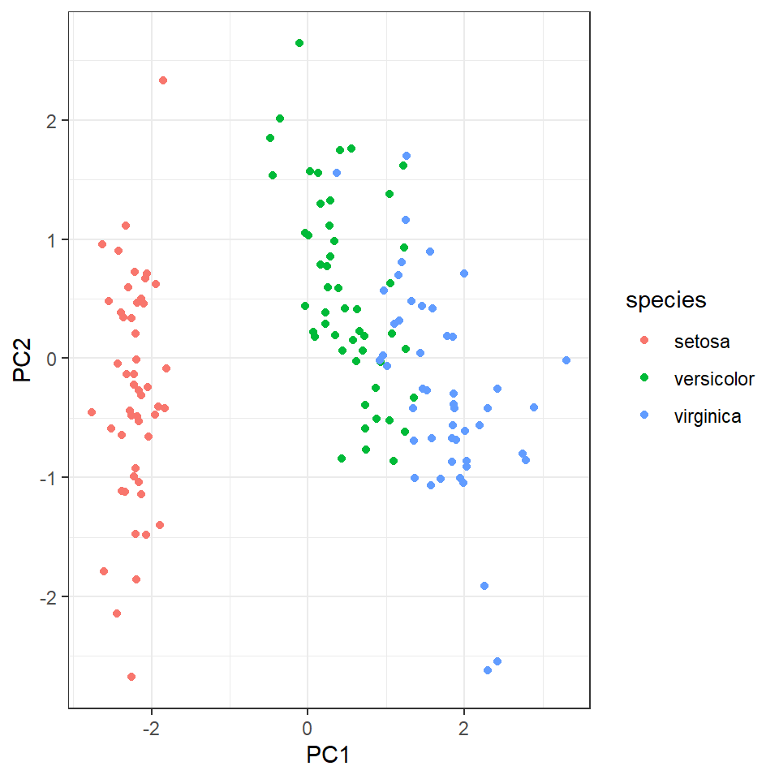

## Putting two plots on one graphics

```r
library(cowplot)
pca12 <- ggplot(df, aes(x=PC1, y=PC2, color=species)) + geom_point()
pca34 <- ggplot(df, aes(x=PC3, y=PC4, color=species)) + geom_point()
plot_grid(pca12, pca34)
```

## Putting two plots on one graphics (cont.)

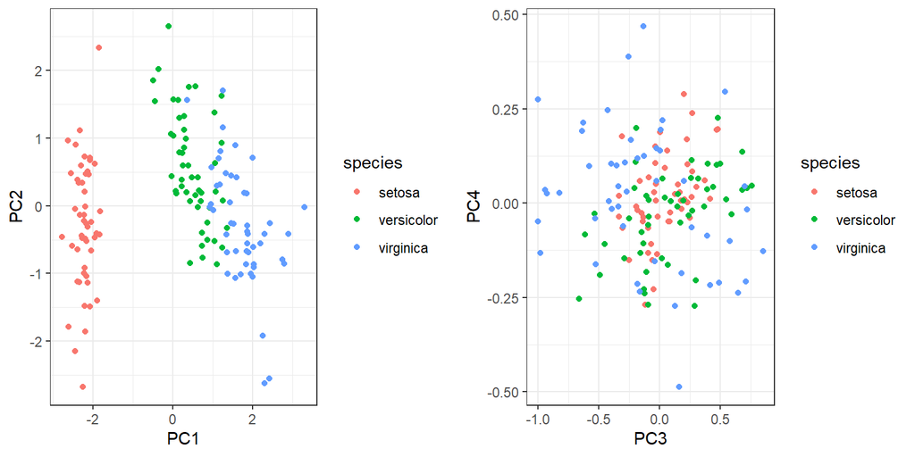

## Playing with PCA: Gene expression

(demonstration)

## Guided Exercise

- Create a subset of `labwide` containing only data for D1 and either Fluad or placebo. Call it `labw_sel`.
- Create a data set from labwide: `labw_mtx <- select(labw_sel, ACA:WBC)`
- Compute and display a PCA for the `labw_mtx` data set. Which components appear to be related to the different sample groups?
- Take a look at `pca$rotation`. Order it by the absolute value for the component in which you can see the difference between group. Take a look at the rownames of this sorted matrix. See anything?

## The mtcars data set – correlations & co.

```r
data(mtcars)
pairs(mtcars[,1:5])
cor(mtcars$hp, mtcars$mpg)
cor.test(mtcars$hp, mtcars$mpg)
cor.test(mtcars$hp, mtcars$mpg, method="spearman")
```

## Linear regression

## Calculating linear regression

```r
mod1 <- lm(mpg ~ hp, data=mtcars)
summary(mod1)
mod2 <- lm(mpg ~ hp + disp, data=mtcars)
summary(mod2)
```

## Plotting linear regression: basic

Plotting mod2 would be less trivial, since we only show one predictor variable on the plot, but the model depends on two of them.

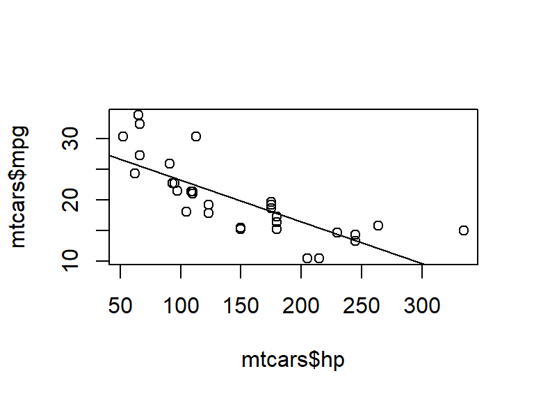

```r
plot(mtcars$hp, mtcars$mpg)
abline(mod1)
```

## Comparing models

```r
mod1 <- lm(mpg ~ hp, data=mtcars)
summary(mod1)
mod2 <- lm(mpg ~ hp + disp, data=mtcars)
summary(mod2)
anova(mod1, mod2)
mod.l <- lm(mpg ~ log(hp), data=mtcars)
BIC(mod1, mod2, mod.l)
```

## Plotting linear regression

Confidence intervals tell us how well we have estimated the relationship. Prediction intervals tell us how well we can predict new data points using this model.

```r
mod <- lm(mpg ~ log(hp), data=mtcars)
xnew <- 50:350
plot(mtcars$hp, mtcars$mpg, log="x", xlab="HP",
  ylab="MPG", bty="n")
ci <- predict(mod, newdata=data.frame(hp=xnew), interval="conf")
lines(xnew, ci[,1], lwd=2) # fit
lines(xnew, ci[,2]) # lower CI
lines(xnew, ci[,3]) # upper CI
pr <- predict(mod, newdata=data.frame(hp=xnew), interval="pred")
lines(xnew, pr[,2], lty=2) # lower prediction
lines(xnew, pr[,3], lty=2) # upper prediction
```

## Plotting linear regression (cont.)

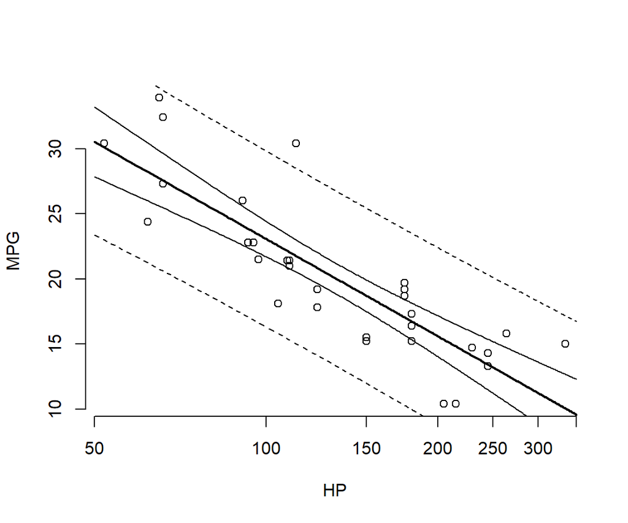

## Plotting linear regression cont.

```r
plot(NULL, xlim=c(50,350), ylim=c(5,45), log="x", xlab="HP",
  ylab="MPG", bty="n")
x2 <- c(xnew, rev(xnew))
polygon(x2, c(pr[,2], rev(pr[,3])), col="#FF330033", border=NA)
polygon(x2, c(ci[,2], rev(ci[,3])), col="#FF330033", border=NA)
lines(xnew, ci[,1], col="#FF3300", lwd=2) # fit
points(mtcars$hp, mtcars$mpg, pch=19, cex=1.3, col="#99110033")
```

## Plotting linear regression cont.

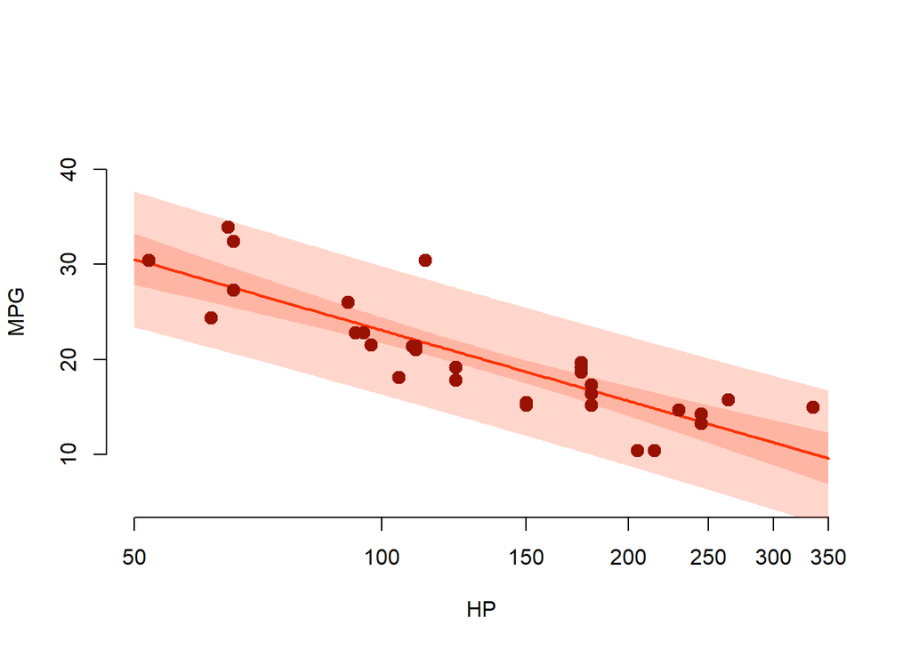

## Heatmaps

## loading data

```r
genes <- read_xlsx("Datasets/expression_data_vaccination_example.xlsx",
  sheet=2)
e <- read_xlsx("Datasets/expression_data_vaccination_example.xlsx",
  sheet=3)
t <- read_xlsx("Datasets/expression_data_vaccination_example.xlsx",
  sheet=1)
res <- read.csv("Datasets/transcriptomics_results.csv")

## res and genes are not identical!
com <- intersect(genes$ProbeName, res$ProbeName)
e <- data.matrix(e[ match(com, genes$ProbeName), ])
genes <- genes[ match(com, genes$ProbeName), ]
rownames(e) <- genes$GeneName
res <- res[ match(com, res$ProbeName), ]
all(res$ProbeName == genes$ProbeName)
```

## Selecting genes to plot on a heatmap

```r
n <- 25 # top 50
byqval <- order(res$qval.F.D1)
sel <- byqval[1:n]

downreg <- which(res$logFC.F.D1 < 0)
downreg <- byqval[ byqval %in% downreg ][1:n]

sel <- c(sel, downreg)


## ordering and selecting columns
group <- paste0(t$ARM, ".", t$Timepoint)
csel <- order(group)
## FLUAD only
csel <- csel[ csel %in% which(t$ARM == "FLUAD") ]
```

## Plotting the heatmap

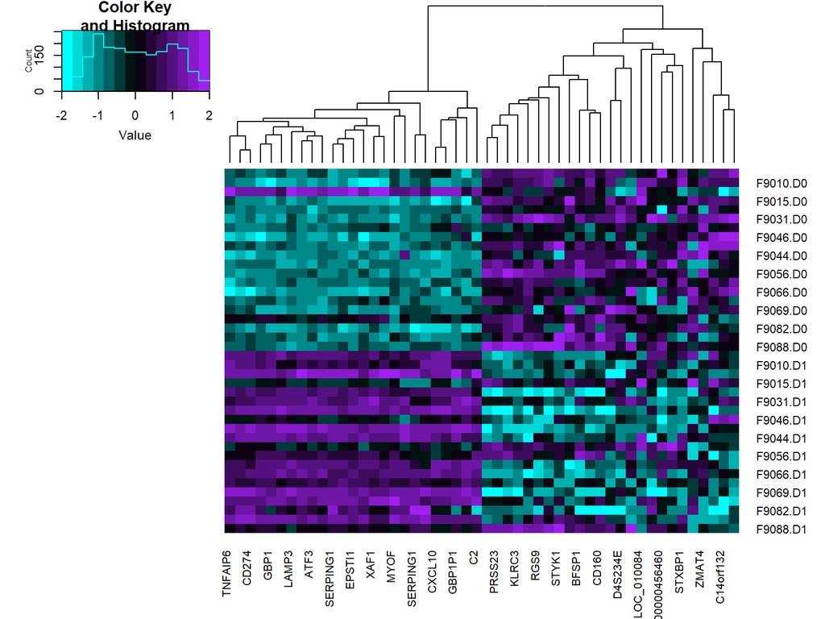

```r
library(gplots)
mtx <- t(e[sel, csel])

## scale manually
mtx <- scale(mtx)

## palette
pal <- colorRampPalette(c("cyan", "black", "purple"))
heatmap.2(mtx, trace="n", scale="n", dendrogram="c",
  Rowv=FALSE, col=pal,
  breaks=seq(-2, 2, length.out=15) )
```

## Simple clustering

## Hierarchical clustering

```r
data(iris)
mtx <- data.matrix(iris[,1:4])
mtx <- scale(mtx)
group <- factor(iris[,5])

dd <- dist(mtx)
tree <- hclust(dd)
cl <- cutree(tree, k=3)
table(cl, group)
```

## K-means clustering

```r
n.cl <- 3
km <- kmeans(mtx, n.cl)
table(km$cluster, group)
pal <- brewer.pal(n=n.cl, name="Dark2")
```

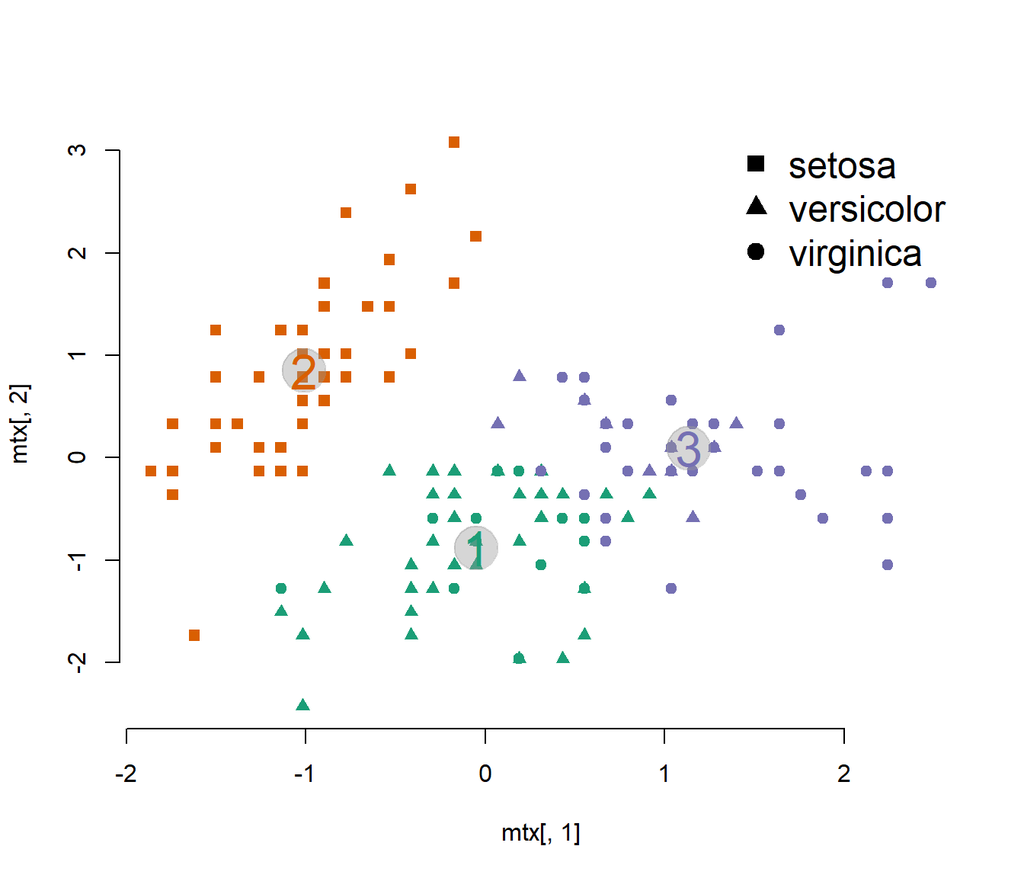

```r
plot(mtx[,1], mtx[,2], col=pal[km$cluster], pch=c(15,17,19)[factor(iris[,5])], bty="n")
points(km$centers[,1], km$centers[,2], pch=19, cex=4, col="#99999966")
text(km$centers[,1], km$centers[,2], 1:n.cl, cex=2, col=pal)
legend("topright", levels(group), pch=c(15,17,19), cex=1.5, bty="n")
```

## Summary

## Let’s bring all concepts together

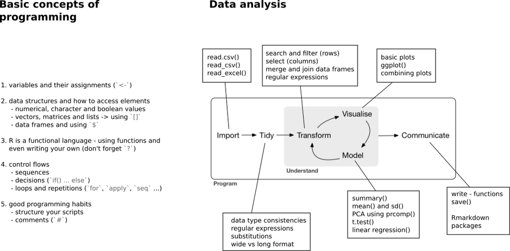